# QTM 151 - Introduction to Statistical Computing II

Lecture 17 - Introduction to SQL with SQLite

Danilo Freire

danilo.freire@emory.edu

Emory University

# Hello, everyone! 😊 Nice to see you again!

# Some reminders 🤓

## Final Project 📖

- **Task**: Write a report on a data analysis project based on the Formula 1 datasets
- **Groups**: 3-4 students
- **Submission**: HTML file from Jupyter Notebook
- **Resources**: [GitHub repository](https://github.com/danilofreire/qtm151/tree/main/final-project)
- **More information**: [Final Project Instructions](https://github.com/danilofreire/qtm151/blob/main/final-project/final-project.pdf)

## Other reminders 📝

### Quizzes

- We will have three quizzes until the end of the semester
- Why more quizzes now? Because you are more familiar with the content and are doing great! 🚀
- The next quiz will cover Python, not SQL
- As usual, I will post a repository link right before the quiz starts
- But so far you guys are doing very well, congratulations! 🎉
- Now let’s move on to today’s topic: **Introduction to SQL with SQLite** 📊🧑🏻‍💻👩🏼‍💻

# What is SQL? 🤔

## What is SQL?

- SQL stands for **Structured Query Language**
- It is a domain-specific language used in programming and designed for managing data held in a relational database management system (RDBMS)
- SQL is widely used in industry and academia
- Its main task is to extract data from a database
- Many concepts are similar to Python
- SQL is actually [quite easy to learn](https://sqlbolt.com/) and very powerful
  - It is a great skill to have in your toolbox! 🧰

[figure not shown]

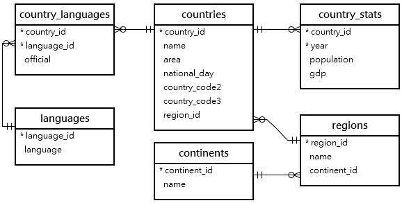

## SQLite 🪶

- We will use [SQLite](https://www.sqlite.org/index.html) as our database management system for this lecture.
- SQLite is a C-language library that implements a small, fast, self-contained, high-reliability, full-featured, SQL database engine.
- It’s the most used database engine in the world! 🌍
- **Key features**:
  - **Serverless**: SQLite reads and writes directly to ordinary disk files. A complete SQL database with multiple tables, indices, triggers, and views, is contained in a single disk file.
  - **Self-contained**: Requires no external dependencies.
  - **Transactional**: ACID compliant, ensuring reliable transactions.
  - **Zero-configuration**: No setup or administration needed.
- It’s excellent for learning SQL, local development, testing, and applications that need a simple, embedded database.

[figure not shown]

[SQLite Logo](https://www.sqlite.org/index.html)

## Getting started with SQLite

- The best part about SQLite is that there’s usually **no installation required**! 🎉
- It’s likely already included with your operating system or Python installation.
- We will primarily interact with SQLite databases using:
  1. **Python**: Using the built-in `sqlite3` module (we’ll see this later).
  2. **VSCode Extensions**: For browsing and querying `.sqlite` or `.db` files directly within VSCode.

### VSCode Extension for SQLite

- To easily view and manage SQLite database files, we recommend installing a VSCode extension.
- A popular choice is [**SQLite** by alexcvzz](https://marketplace.visualstudio.com/items?itemName=alexcvzz.vscode-sqlite).
- Go to the Extensions view (`Ctrl+Shift+X` or `Cmd+Shift+X`) and search for “SQLite”. Install the one by alexcvzz.
- This extension allows you to:
  - Open `.sqlite` or `.db` files (it will create one if it doesn’t exist).
  - Explore the database by clicking the SQLite icon in the activity bar.
  - See the database schema (tables, columns).
  - Run SQL queries directly against the database file using `.sql` files or the query editor.

[figure not shown]

*Searching for the SQLite extension in VSCode.*

# Ready to use SQLite? Let’s create a database! 🧑🏻‍💻

## Creating a database file and SQL script

- Ensure you have the [**SQLite** by alexcvzz](https://marketplace.visualstudio.com/items?itemName=alexcvzz.vscode-sqlite) extension installed.
- Using the VSCode File Explorer, create a new, empty file named `lecture17.sqlite` in the current directory (`lectures/lecture-17/`). This file will hold our database.
- Create another new file named `17-introduction-sql.sql` (or use the existing one if you prefer, just clear its contents). This will be our SQL script file.
- Open the `17-introduction-sql.sql` file.
- At the top of the editor, you should see a toolbar from the SQLite extension. Click the database icon (`Choose Database`) and select `Attach existing database`. Choose the `lecture17.sqlite` file you just created.
- Now, any SQL command you run in this `.sql` file will be executed against the `lecture17.sqlite` database file.

[figure not shown]

*Connecting the .sql file to the SQLite database file.*

## Let’s write some SQL code!

- Now that our `.sql` file is connected to the `lecture17.sqlite` database, we can write and run SQL commands.
- We will start by creating a table from scratch.
- It is good practice to check if the table already exists and drop it if it does.
- This way we avoid errors and can start fresh 🤓.
- Since we’ve been talking about [Formula 1](https://en.wikipedia.org/wiki/Formula_One), let’s create a table with some information about drivers.
- System commands are often in upper case and user-defined names are often in lower case by convention.

```sql
-- Drop the table if it already exists
DROP TABLE IF EXISTS drivers;

-- Create the drivers table
CREATE TABLE drivers(
    driver_id INTEGER PRIMARY KEY, -- Use INTEGER PRIMARY KEY for auto-increment in SQLite
    driver_name TEXT,             -- TEXT is common for strings in SQLite
    nationality TEXT,
    victories INTEGER             -- INTEGER is the standard type for integers
);
```

- What are we doing here?
- `DROP TABLE IF EXISTS drivers;`: Removes the `drivers` table if it exists.
- `CREATE TABLE drivers(...)`: Creates an empty `TABLE` called `drivers`.
- Inside the parentheses `(...)`, we define the columns:
  - `driver_id INTEGER PRIMARY KEY`: An integer column that uniquely identifies each driver. In SQLite, this often acts as an auto-incrementing key.
  - `driver_name TEXT`: A column to store the driver’s name as text.
  - `nationality TEXT`: A column for the driver’s nationality.
  - `victories INTEGER`: A column for the number of victories.
- Type the code above into the `17-introduction-sql.sql` editor.
- Select the code you want to run (or place the cursor within a command).
- Right-click and choose `Run Query` or use the shortcut (`Ctrl+Shift+Q` or `Cmd+Shift+Q`).
- Check the `SQLite` output panel for success messages.

## Add rows to table

- Now that we have created the table, let’s add some rows to it!
- We can do this by using the `INSERT INTO` command.
- This command adds rows with `VALUES` to the table.
- In SQL, statements are typically separated by a semicolon (`;`).
- Let’s add some information about the drivers into our `.sql` file:

```sql
-- Insert data into the drivers table
INSERT INTO drivers (driver_name, nationality, victories) VALUES ('Lewis Hamilton','British', 103);
INSERT INTO drivers (driver_name, nationality, victories) VALUES ('Fernando Alonso', 'Spanish', 32);
INSERT INTO drivers (driver_name, nationality, victories) VALUES ('Sebastian Vettel', 'German', 91); -- Note: Original had 91, corrected from 53
INSERT INTO drivers (driver_name, nationality, victories) VALUES ('Michael Schumacher', 'German', 53); -- Note: Original had 53, corrected from 91
```

*Note: We don’t specify `driver_id` here; SQLite will auto-generate it because it’s an `INTEGER PRIMARY KEY`.*

- Select these `INSERT` statements in your `.sql` file and run them using `Run Query`.

## Viewing the data

- How do we see the data we just inserted? We use the `SELECT` command!
- We will learn more about `SELECT` soon, but for now let’s run the following command in our `.sql` file:

```sql
-- Select all data from the drivers table
SELECT * FROM drivers;
```

- This command selects all columns (`*`) from the `drivers` table.
- Run this query (`Ctrl+Shift+Q` or `Cmd+Shift+Q`).
- The results should appear in a new tab! 🎉

[figure not shown]

*Result of SELECT* FROM drivers.*

## Try it yourself! 🧠

- Add two or three more rows to the `drivers` table in your `17-introduction-sql.sql` file.
- Remember to only specify `driver_name`, `nationality`, and `victories`.
- Run the `INSERT` statements.
- Run `SELECT * FROM drivers;` again to see the updated table.
- Here’s some code to help you get started:

```sql
INSERT INTO drivers (driver_name, nationality, victories) VALUES ('Max Verstappen', 'Dutch', 51);
INSERT INTO drivers (driver_name, nationality, victories) VALUES ('Juan Pablo Montoya', 'Colombian', 6);
INSERT INTO drivers (driver_name, nationality, victories) VALUES ('Danilo Freire','Brazilian', 10); -- Let's be optimistic! 😉
```

- Appendix 01

# Interacting with the database in VSCode

## Using the SQLite VSCode Extension

- We’ve already seen how to connect a `.sql` file to our `lecture17.sqlite` database and run queries.
- You write SQL commands directly in the `.sql` file editor.
- To run a command (or selected commands), right-click in the editor and choose `Run Query` or use the shortcut (`Ctrl+Shift+Q` or `Cmd+Shift+Q`).
- The results appear in a separate tab.

[figure not shown]

*Running a query from the .sql file.*

## Exploring the Database

- The SQLite extension also provides a database explorer view.
- Click the SQLite icon in the VSCode Activity Bar (usually on the far left).
- You should see your `lecture17.sqlite` database listed under the “SQLite Explorer” panel.
- Expand it to see the tables (like `drivers`), their columns, and data types.
- You can right-click on tables to perform actions like viewing the data (`Show Table`) or generating `SELECT` statements.

[figure not shown]

*Using the SQLite Explorer in VSCode.*

# So far so good? 😉

# Dataset Operations in SQL 📊

## Extracting columns from table

### SELECT extracts certain columns

- The `SELECT` command is used to extract specific columns from a table.

```sql
SELECT driver_id, nationality FROM drivers;
```

[figure not shown]

### Subsetting rows

- The `WHERE` command evaluates logical conditions to filter rows.

```sql
SELECT * FROM drivers
WHERE nationality = 'German';
```

[figure not shown]

## AND and OR conditions

### OR conditions

- Evaluate OR conditions to select rows matching *either* condition.

```sql
SELECT * FROM drivers
WHERE (nationality = 'Brazilian') OR (nationality = 'German');
```

[figure not shown]

### AND conditions

- Evaluate AND conditions to select rows matching *both* conditions.

```sql
SELECT * FROM drivers
WHERE (nationality = 'German') AND (victories > 60);
```

[figure not shown]

## Other useful commands

### ORDER BY

- Sort results using `ORDER BY`. Default is ascending (`ASC`). Use `DESC` for descending.

```sql
SELECT * FROM drivers
ORDER BY victories DESC;
```

[figure not shown]

### LIMIT

- Limit the number of rows returned using `LIMIT`.

```sql
SELECT * FROM drivers
ORDER BY victories DESC
LIMIT 3; -- Get the top 3 drivers by victories
```

[figure not shown]

## DISTINCT values

- The `DISTINCT` keyword returns only unique values for a column.

```sql
SELECT DISTINCT nationality FROM drivers;
```

[figure not shown]

## Basic calculations

- You can perform calculations directly in `SELECT`. Use `AS` to name the result column.

```sql
SELECT
    driver_name,
    victories,
    victories * 1.1 AS victories_plus_10_percent
FROM drivers;
```

[figure not shown]

## Aggregate functions

- SQL has functions to summarize data: `COUNT`, `SUM`, `AVG`, `MIN`, `MAX`.

```sql
SELECT COUNT(*) AS total_drivers FROM drivers;

SELECT SUM(victories) AS total_victories FROM drivers;

SELECT AVG(victories) AS average_victories FROM drivers;

SELECT MAX(victories) AS max_victories FROM drivers;
```

[figure not shown]

## GROUP BY

- `GROUP BY` groups rows with the same values in specified columns, allowing aggregate functions per group.

```sql
SELECT
    nationality,
    COUNT(*) AS number_of_drivers,
    AVG(victories) AS avg_victories_per_nationality
FROM drivers
GROUP BY nationality
ORDER BY number_of_drivers DESC;
```

[figure not shown]

# Questions? 🤔

# Appendix

## Appendix 01

- Here’s the full table after adding the extra drivers from the exercise:

```sql
SELECT * FROM drivers ORDER BY driver_id;
```

| driver_id | driver_name | nationality | victories |
| --- | --- | --- | --- |
| 1 | Lewis Hamilton | British | 103 |
| 2 | Fernando Alonso | Spanish | 32 |
| 3 | Sebastian Vettel | German | 91 |
| 4 | Michael Schumacher | German | 53 |
| 5 | Max Verstappen | Dutch | 51 |
| 6 | Juan Pablo Montoya | Colombian | 6 |
| 7 | Danilo Freire | Brazilian | 10 |

*Note: The exact `driver_id` values might differ if you dropped and recreated the table multiple times, but the relative order should be similar.*